# Demographics

Sofia Pozsonyiova

4/21/2020

According to Ton MCG…the state of alask resports results at the precinct or state level; no county level data available

```r
require(choroplethr)
require(dplyr)
require(readr)
```

State Specific Demographics

```r
data("df_state_demographics")
```

Election Data

```r
election <- read.csv("https://raw.githubusercontent.com/tonmcg/County_Level_Election_Results_12-16/master/US_County_Level_Presidential_Results_08-16.csv")
election <- election %>% mutate(region = fips_code)
```

County Names + State:

```r
data("df_county_demographics")
RedBlue <- read.csv("https://www.macalester.edu/~ajohns24/Data/RedBluePurple.csv")
```

Combining County and State: (df_county) + redblue

```r
county_level_demographic_data <- left_join(df_county_demographics,RedBlue)
abb_added <- county_level_demographic_data %>% select(polyname,abb,StateColor,region)
```

Combining elect and abb:

```r
full_data_county <- left_join(election,abb_added, by = "region")
County_level_data <- read.csv("/Users/sofiapozsonyiova/Desktop/COVID-19Bayes/Demographic_Data_/full_data_by_county.csv")
County_level_data <-County_level_data
```

```r
county_final<- County_level_data %>% group_by(polyname, abb, StateColor) %>% summarise_if(is.numeric, sum, na.rm = TRUE)
state_demographics <- df_state_demographics %>% mutate(polyname = region)
state_demographics <- state_demographics %>% select(-region)
county_final <- county_final %>% select(-region)

combineddata <- left_join(county_final,state_demographics, by = "polyname")

Demographic_Data_variables <- combineddata %>%
  select(-c(fips_code,total_2008,dem_2008,gop_2008,oth_2008,total_2012,dem_2012,gop_2012,oth_2012))%>%
  mutate(percent_white = percent_white/100) %>%
  mutate(percent_black = percent_black/100) %>%
  mutate(percent_asian = percent_asian/100) %>%
  mutate(percent_hispanic = percent_hispanic/100) %>%
  mutate(percent_democrat2016 = dem_2016/total_2016) %>%
  mutate(percent_republican2016 = gop_2016/total_2016) %>%
  mutate(percent_other2016 = oth_2016/total_2016) %>%
  mutate(Winner = ifelse(percent_republican2016 > percent_democrat2016 & percent_republican2016 > percent_other2016, "Republican", "Democrat"))%>% filter(total_2016 != 635888)
#Saving
#write.csv(Demographic_Data_variables,"Demographic_Data.csv")
```

OUR DATA

```r
FinalDemographic <- read.csv("/Users/sofiapozsonyiova/Desktop/COVID-19Bayes/Demographic_Data_/FINALDemographic_Data.csv")
#save(FinalDemographic, file = 'FinalDemographic.RData')
```

Data:

Our dataset, `Demographic`, was created by merging three other datasets which all contained different demographic and election information. We obtained the main portion of our demographic data from the US Census Bureau’s American Community Survey (ACS) which is an ongoing survey administered by the U.S. Census Bureau. It gathers information on characteristics like income, employment, and housing annually for all the 50 U.S. States on the county and state level. To access the county-level dataset we used the R package called Choroplethr which provides API connections to data sources like the ACS. The ACS County-Level dataset was then merged with a county-level election outcome dataset that was created by Tony McGoven. Tony’s dataset contained presidential election results for 2008,2012, and 2016 but we chose to focus solely on the most recent election,2016. That said, the 2016 election results at the county-level were scraped from results published by Townhall.com. However, the State of Alaska reports results at the precinct or state level so there was no county-level data available. Therefore, another dataset had to be created that contained the election results for Alaska and this was done using the official election results provided by the Alaska Division of Elections and was later merged in. The final dataset that was used came from Alicia Johnson and it contained information on a state’s political leaning. Meaning it categorizes each county as belonging to a blue/red/purple state based on the state categorizations at 279towin.

Information on the data itself:

```r
#Dimensions:
dim(FinalDemographic)
```

```
## [1] 51 19
```

```r
#51 Observations and 19 variables

#Variable Names:
names(FinalDemographic)
```

```
##  [1] "polyname"               "abb"
##  [3] "StateColor"             "total_2016"
##  [5] "dem_2016"               "gop_2016"
##  [7] "oth_2016"               "total_population"
##  [9] "percent_white"          "percent_black"
## [11] "percent_asian"          "percent_hispanic"
## [13] "per_capita_income"      "median_rent"
## [15] "median_age"             "percent_democrat2016"
## [17] "percent_republican2016" "percent_other2016"
## [19] "Winner"
```

```r
#Head:
head(FinalDemographic)
```

```
##     polyname abb StateColor total_2016 dem_2016 gop_2016 oth_2016
## 1    alabama  AL        red    2078165   718084  1306925    53156
## 2     alaska  AK        red     318608   116454   163387    38767
## 3    arizona  AZ        red    2062810   936250  1021154   105406
## 4   arkansas  AR        red    1108615   378729   677904    51982
## 5 california  CA       blue    9631972  5931283  3184721   515968
## 6   colorado  CO       blue    2564185  1212209  1137455   214521
##   total_population percent_white percent_black percent_asian
## 1          4799277          0.67          0.26          0.01
## 2           741456          0.65          0.04          0.07
## 3          6479703          0.57          0.04          0.03
## 4          2933369          0.74          0.15          0.01
## 5         37659181          0.40          0.06          0.13
## 6          5119329          0.70          0.04          0.03
##   percent_hispanic per_capita_income median_rent median_age
## 1             0.04             23680         501       38.1
## 2             0.07             34922          NA       34.7
## 3             0.30             25358         747       36.3
## 4             0.07             22170         480       37.5
## 5             0.38             29527        1119       35.4
## 6             0.21             31109         825       36.1
##   percent_democrat2016 percent_republican2016 percent_other2016     Winner
## 1            0.3455375              0.6288841        0.02557834 Republican
## 2            0.3655087              0.5128151        0.12167617 Republican
## 3            0.4538712              0.4950306        0.05109826 Republican
## 4            0.3416236              0.6114873        0.04688914 Republican
## 5            0.6157911              0.3306406        0.05356826   Democrat
## 6            0.4727463              0.4435932        0.08366050   Democrat
```

```r
#Summary:
summary(FinalDemographic)
```

```
##        polyname       abb      StateColor   total_2016
##  alabama   : 1   AK     : 1   blue  :19   Min.   : 248742
##  alaska    : 1   AL     : 1   purple:11   1st Qu.: 736089
##  arizona   : 1   AR     : 1   red   :21   Median :1922218
##  arkansas  : 1   AZ     : 1               Mean   :2489256
##  california: 1   CA     : 1               3rd Qu.:3076760
##  colorado  : 1   CO     : 1               Max.   :9631972
##  (Other)   :45   (Other):45
##     dem_2016          gop_2016          oth_2016      total_population
##  Min.   :  55949   Min.   :  11553   Min.   :  8496   Min.   :  570134
##  1st Qu.: 270342   1st Qu.: 371301   1st Qu.: 42364   1st Qu.: 1712494
##  Median : 779535   Median : 947934   Median : 91364   Median : 4361333
##  Mean   :1188393   Mean   :1179254   Mean   :121608   Mean   : 6108975
##  3rd Qu.:1529104   3rd Qu.:1526458   3rd Qu.:173075   3rd Qu.: 6712318
##  Max.   :5931283   Max.   :4681590   Max.   :515968   Max.   :37659181
##
##  percent_white    percent_black    percent_asian     percent_hispanic
##  Min.   :0.2300   Min.   :0.0000   Min.   :0.01000   Min.   :0.0100
##  1st Qu.:0.5950   1st Qu.:0.0300   1st Qu.:0.01000   1st Qu.:0.0450
##  Median :0.7400   Median :0.0700   Median :0.02000   Median :0.0800
##  Mean   :0.7029   Mean   :0.1084   Mean   :0.03765   Mean   :0.1082
##  3rd Qu.:0.8250   3rd Qu.:0.1450   3rd Qu.:0.04000   3rd Qu.:0.1250
##  Max.   :0.9400   Max.   :0.4900   Max.   :0.37000   Max.   :0.4700
##
##  per_capita_income  median_rent       median_age    percent_democrat2016
##  Min.   :20618     Min.   : 448.0   Min.   :29.60   Min.   :0.2249
##  1st Qu.:24908     1st Qu.: 565.0   1st Qu.:36.30   1st Qu.:0.3612
##  Median :26824     Median : 658.0   Median :37.60   Median :0.4670
##  Mean   :28098     Mean   : 714.3   Mean   :37.66   Mean   :0.4501
##  3rd Qu.:30144     3rd Qu.: 835.5   3rd Qu.:38.95   3rd Qu.:0.5252
##  Max.   :45290     Max.   :1220.0   Max.   :43.20   Max.   :0.9285
##                    NA's   :1
##  percent_republican2016 percent_other2016        Winner
##  Min.   :0.04122        Min.   :0.01937   Democrat  :21
##  1st Qu.:0.41472        1st Qu.:0.04262   Republican:30
##  Median :0.49064        Median :0.05071
##  Mean   :0.49010        Mean   :0.05976
##  3rd Qu.:0.57641        3rd Qu.:0.06860
##  Max.   :0.70052        Max.   :0.25598
##
```

| Variables: | Meaning: |
| --- | --- |
| `polyname` | State Name |
| `StateColor` | Political Leaning |
| `percent_hispanic` | Percent of the Population that is Hispanic |
| `percent_white` | Percent of the Population that is White |
| `percent_asian` | Percent of the Population that is Asian |
| `percent_black` | Percent of Population that is Black |
| `total_population` | Total State Population |
| `per_capita_income` | Income per Capita |
| `percent_democrat2016` | Percent of votes won by Democrat (Clinton) |
| `percent_republican2016` | Percent of votes won by Republican (Trump) |
| `Winner` | Indicator for whether a Republican or Democrat Won |
| `total_2016` | Total Number of Votes |

```r
library(choroplethrMaps)
library(usmap)
library(ggplot2)


mapdata <- FinalDemographic %>% mutate(state = polyname)

# plot_usmap(data = dat_sub, values = 'total.receipts', color = "red") +
#   scale_fill_continuous(low = "white", high = "blue", name = "Total Receipts", label = scales::comma) + theme(legend.position = "right") + facet_wrap(~party)
```

Visualizations:

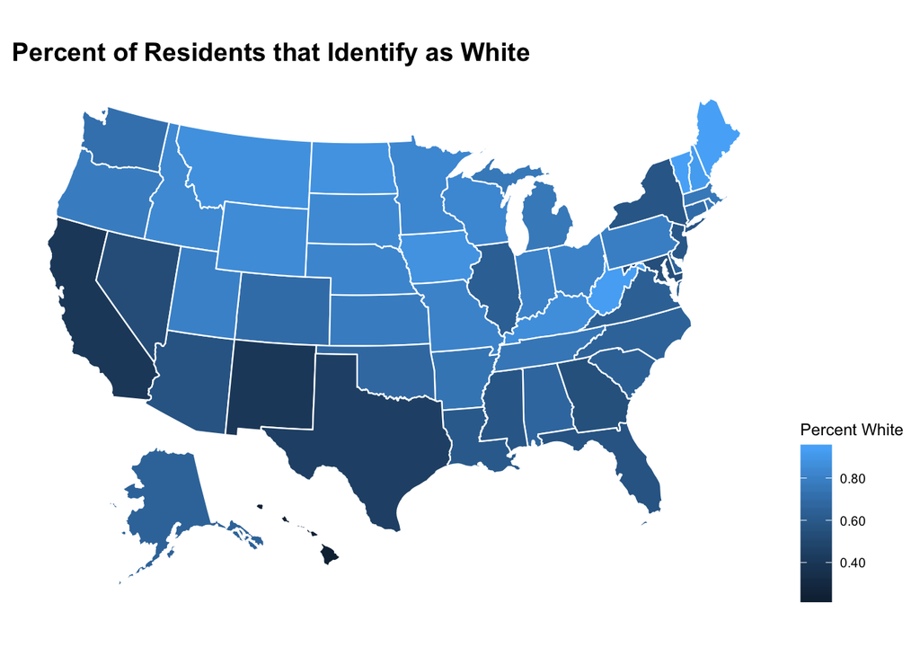

```r
#Demographic: Identification
plot_usmap(data = mapdata, values = "percent_white", color = "white") +
  scale_fill_continuous(name = "Percent White", label = scales::comma) +
  theme(legend.position = "right")+ ggtitle("Percent of Residents that Identify as White") +
  theme(
plot.title = element_text(color="Black", size=14, face="bold")
)
```

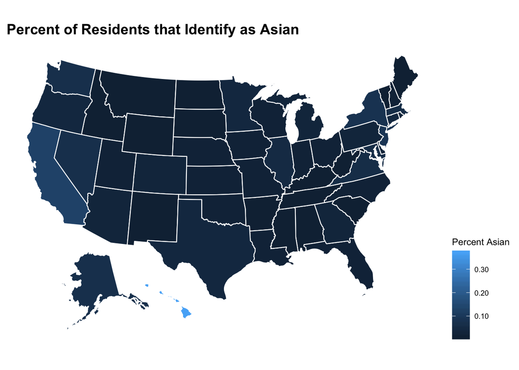

```r
plot_usmap(data = mapdata, values = "percent_asian", color = "white") +
  scale_fill_continuous( name = "Percent Asian", label = scales::comma) +
  theme(legend.position = "right") + ggtitle("Percent of Residents that Identify as Asian") +
  theme(
plot.title = element_text(color="Black", size=14, face="bold")
)
```

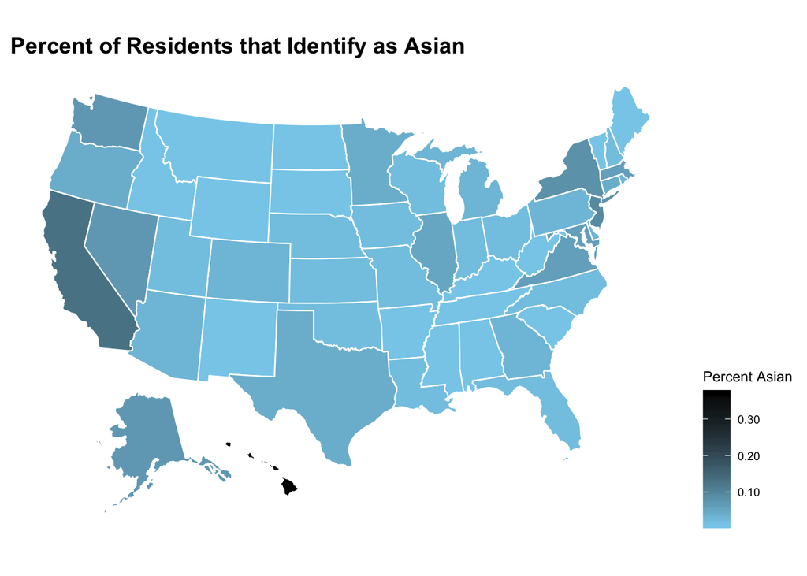

```r
plot_usmap(data = mapdata, values = "percent_asian", color = "white") +
  scale_fill_continuous(low = "sky blue", high = "black", name = "Percent Asian", label = scales::comma) +
  theme(legend.position = "right") + ggtitle("Percent of Residents that Identify as Asian") +
  theme(
plot.title = element_text(color="Black", size=14, face="bold")
)
```

Polling Visualizations:

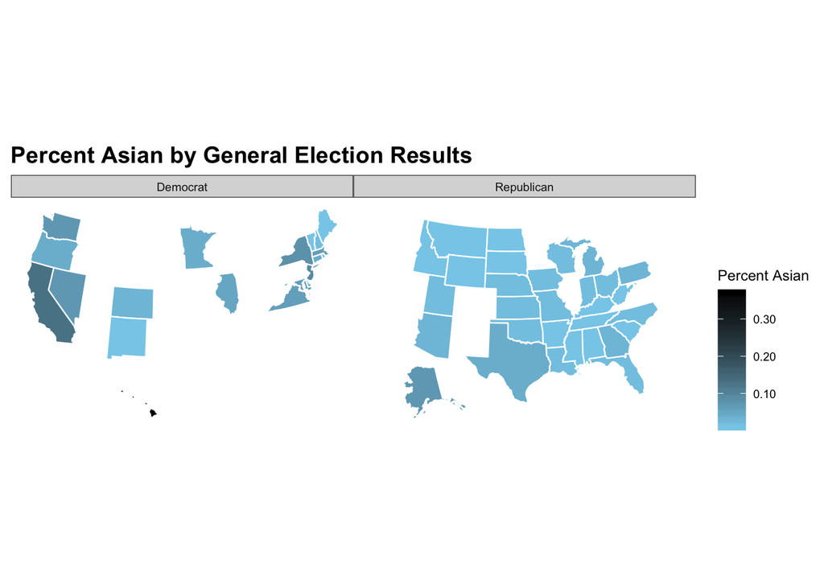

```r
#By Results
plot_usmap(data = mapdata, values = "percent_asian", color = "white") +
  scale_fill_continuous(low = "sky blue", high = "black", name = "Percent Asian", label = scales::comma) +
  theme(legend.position = "right") + ggtitle("Percent Asian by General Election Results")+
  theme(
plot.title = element_text(color="Black", size=14, face="bold")
) + facet_wrap(~Winner)
```

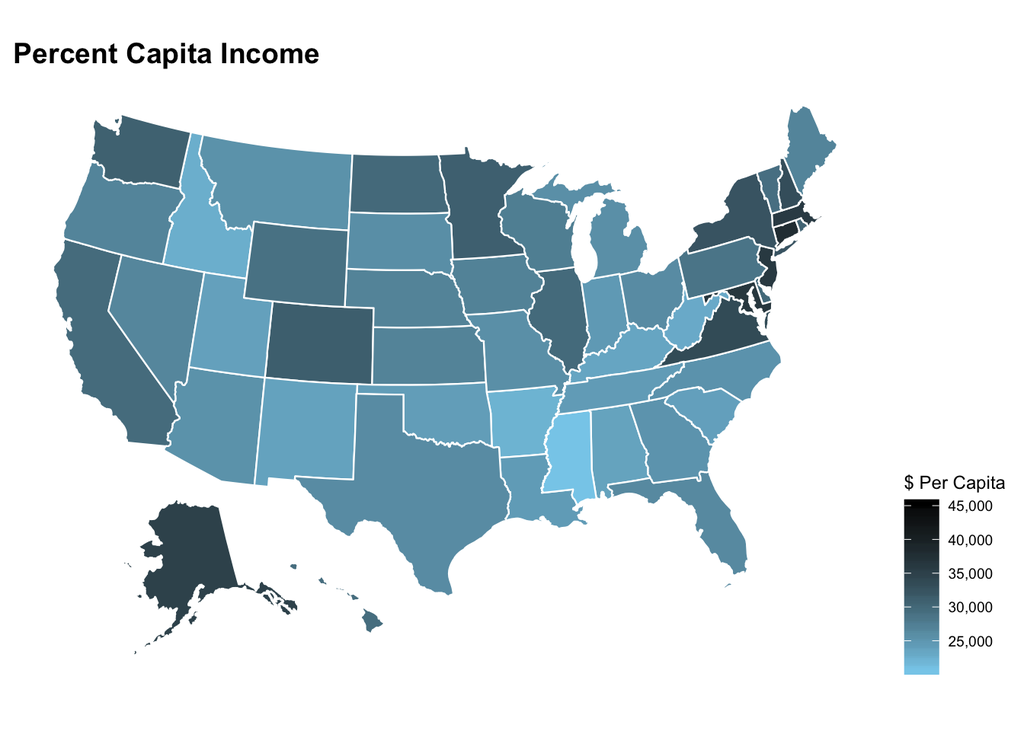

```r
#By income
plot_usmap(data = mapdata, values = "per_capita_income", color = "white") +
  scale_fill_continuous(low = "sky blue", high = "black", name = "$ Per Capita", label = scales::comma) +
  theme(legend.position = "right") + ggtitle("Percent Capita Income")+
  theme(
plot.title = element_text(color="Black", size=14, face="bold")
)
```

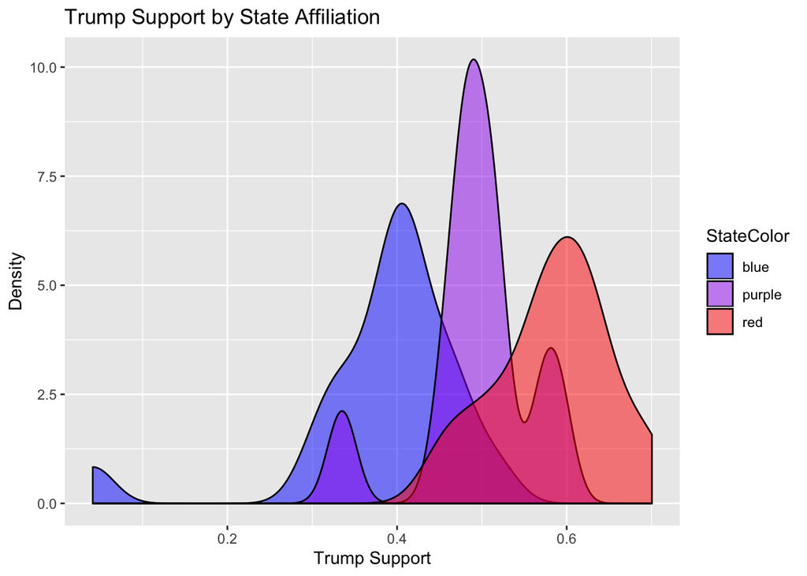

```r
ggplot(mapdata, aes(x = percent_republican2016, fill = StateColor)) +
    geom_density(alpha = 0.5) +
    scale_fill_manual(values = c("blue","purple","red")) +ggtitle("Trump Support by State Affiliation") + xlab("Trump Support")+ylab("Density")
```

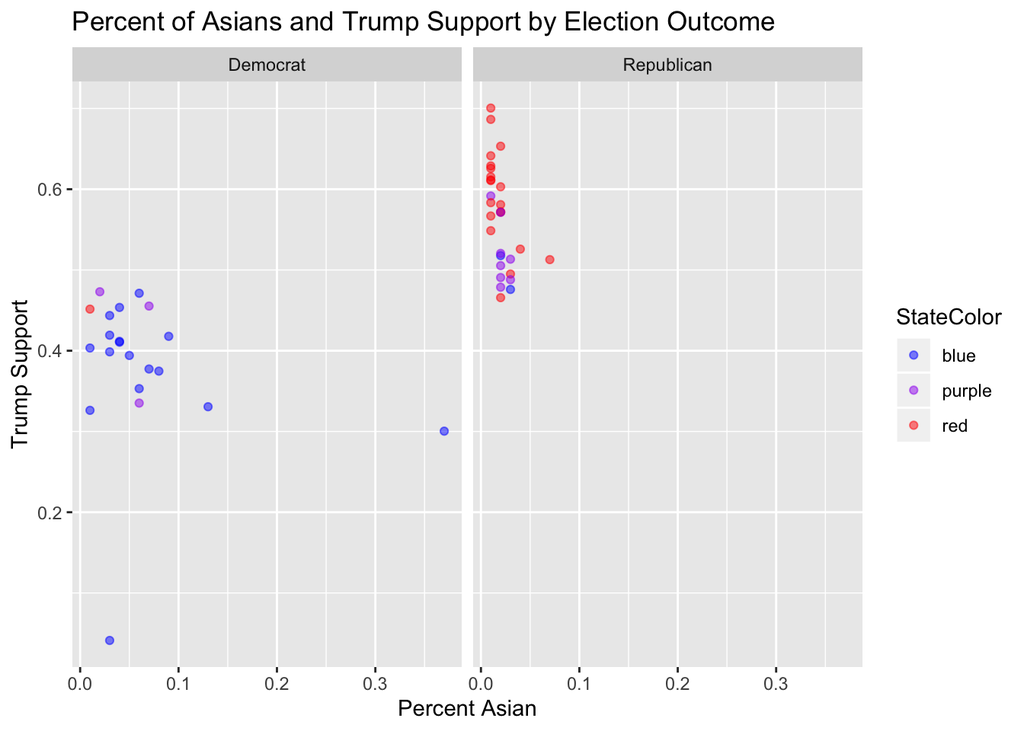

```r
ggplot(mapdata, aes(x = percent_asian, y = percent_republican2016, color = StateColor)) +
    geom_point(alpha = 0.5) +
    scale_color_manual(values = c("blue","purple","red")) +
    facet_wrap( ~ Winner) + ggtitle("Percent of Asians and Trump Support by Election Outcome") + xlab("Percent Asian") + ylab("Trump Support")
```

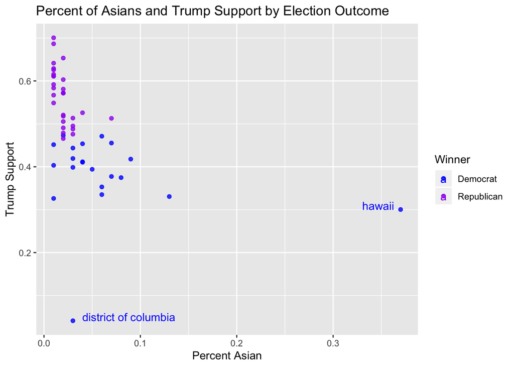

```r
ggplot(mapdata, aes(x = percent_asian, y = percent_republican2016, color = Winner)) +
    scale_color_manual(values = c("blue","purple","red")) +
    geom_point(alpha = 0.8) + geom_text(aes(label=ifelse(percent_asian>.2,as.character(state),"")),hjust=1.2,vjust=0)+ geom_text(aes(label=ifelse(percent_republican2016<.2,as.character(state),"")),hjust=-.1,vjust=0) + ggtitle("Percent of Asians and Trump Support by Election Outcome") + xlab("Percent Asian") + ylab("Trump Support")
```

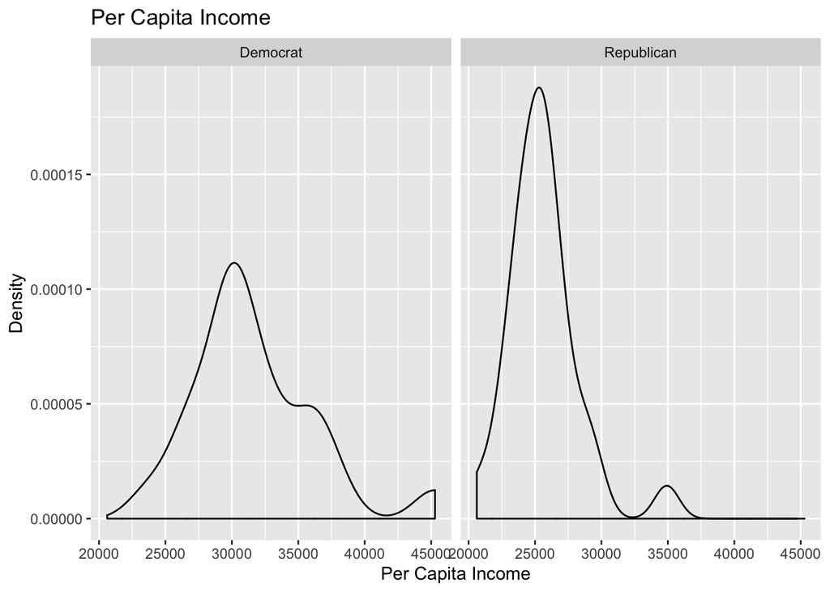

```r
ggplot(mapdata, aes(x = per_capita_income)) +
    geom_density()+ ggtitle("Per Capita Income") + xlab("Per Capita Income") + ylab("Density") + facet_wrap(~Winner)
```

Univariate Plots

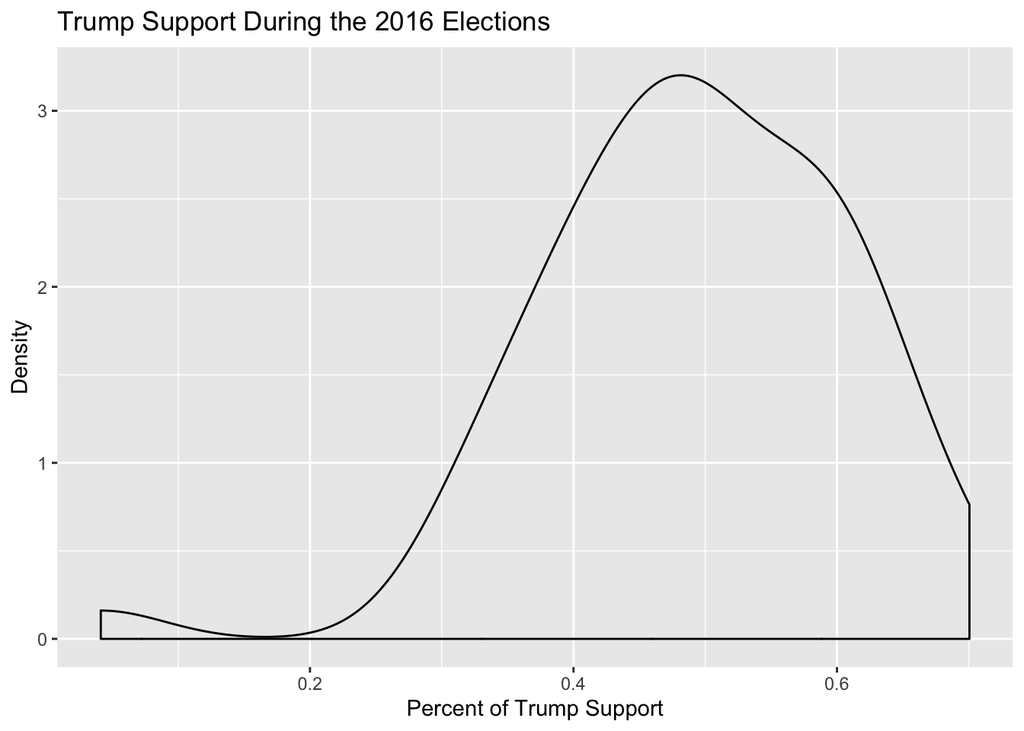

```r
ggplot(mapdata, aes(x = percent_republican2016)) +
    geom_density()+ ggtitle("Trump Support During the 2016 Elections") + xlab("Percent of Trump Support") + ylab("Density")
```

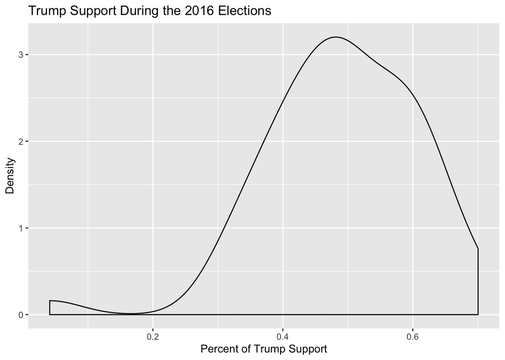

```r
ggplot(mapdata, aes(x = percent_republican2016)) +
    geom_density()+ ggtitle("Trump Support During the 2016 Elections") + xlab("Percent of Trump Support") + ylab("Density")
```

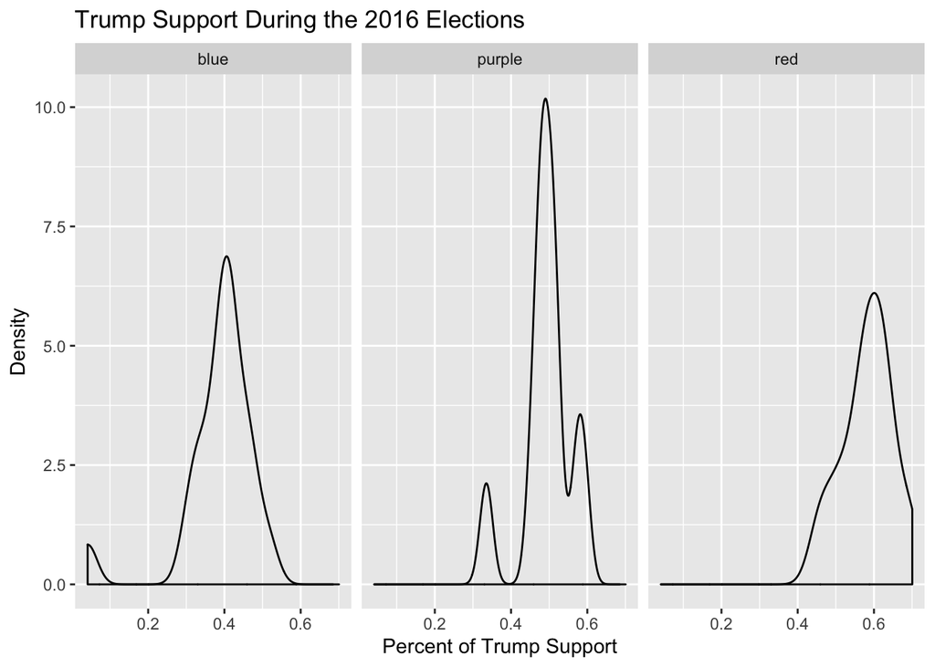

```r
ggplot(mapdata, aes(x = percent_republican2016)) +
    geom_density()+ ggtitle("Trump Support During the 2016 Elections") + xlab("Percent of Trump Support") + ylab("Density") + facet_wrap(~StateColor)
```

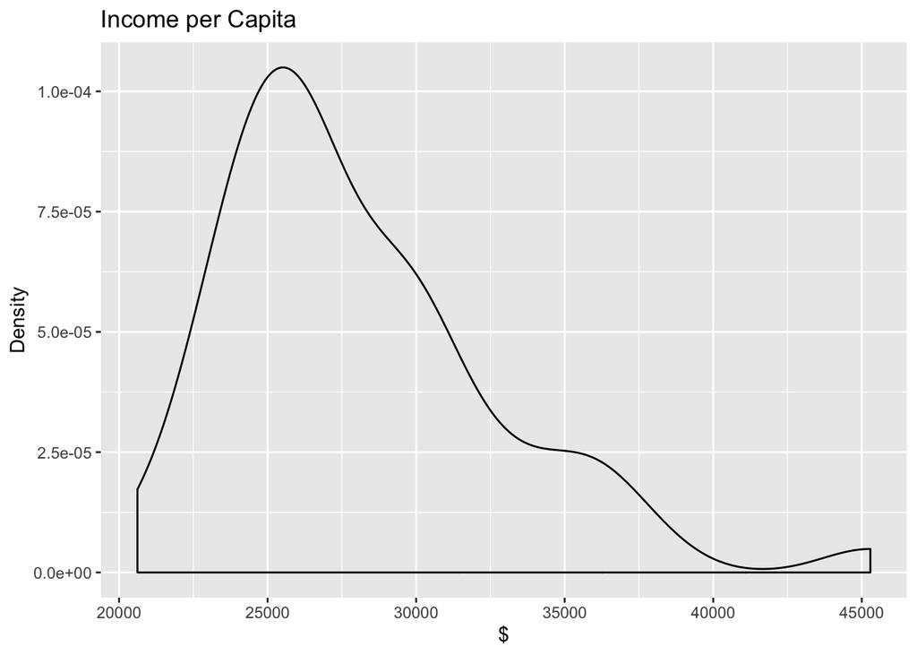

```r
ggplot(mapdata, aes(x = per_capita_income)) +
    geom_density()+ ggtitle("Income per Capita") + xlab("$") + ylab("Density")
```

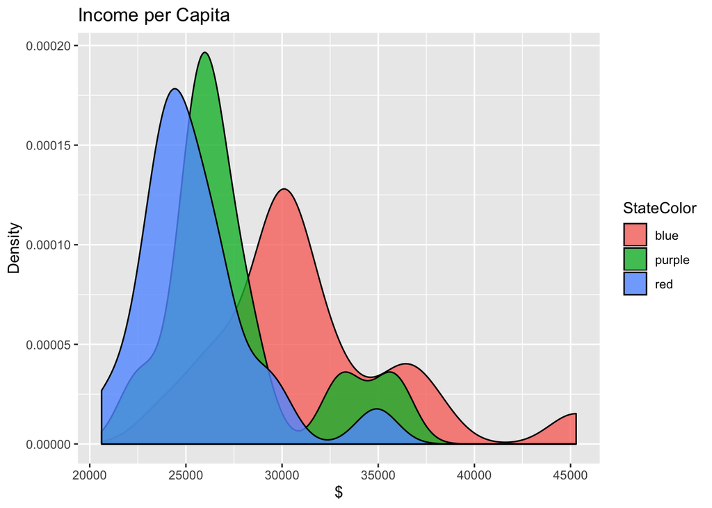

```r
ggplot(mapdata, aes(x = per_capita_income, fill = StateColor)) +
    geom_density(alpha = .8)+ ggtitle("Income per Capita") + xlab("$") + ylab("Density")
```